# Lab 2: Get Acquainted with Data Science Tools and Perform Statistical Analysis

### Objectives:

1. Learn about Python libraries for data science.
2. Explore and practice data analysis using these libraries.
3. Perform statistical analysis to extract insights from data.

### Python Libraries Covered:

- **NumPy**: Efficient handling of numerical data.
- **Pandas**: Data manipulation and analysis.
- **Matplotlib & Seaborn**: Data visualization tools.
- **SciPy**: Advanced statistical functions.

### Instructions:

- Carefully follow the examples provided for each library.
- Solve the practice questions included.

Ensure you have these libraries installed. If not, install them using pip:

```
pip install numpy pandas matplotlib seaborn scipy
```

```python
# pip install numpy pandas matplotlib seaborn scipy
```

## Performing Statistical Analysis

### 1. Descriptive Statistics

Descriptive statistics summarize and describe the main features of a dataset.

We'll calculate:

### 2. Inferential Statistics

Inferential statistics allow us to make predictions or inferences about a population based on a sample.

## 1. NumPy: Numerical Python

NumPy is a library used for numerical computations. It provides:

- Support for multi-dimensional arrays.
- Functions for mathematical and statistical operations.

### Basic Operations

Below are examples to get started with NumPy arrays and operations.

```python
import numpy as np

# Creating a NumPy array
arr = np.array([1, 2, 3, 4, 5])
print("Array:", arr)

# Array operations
print("Array multiplied by 2:", arr * 2)
print("Array mean:", np.mean(arr))
print("Array standard deviation:", np.std(arr))
```

```
Array: [1 2 3 4 5]
Array multiplied by 2: [ 2  4  6  8 10]
Array mean: 3.0
Array standard deviation: 1.4142135623730951
```

### Practice Questions:

1. Create a NumPy array with numbers from 1 to 10 and calculate the sum.
2. Create a 3x3 matrix with random numbers and find its transpose.
3. Generate an array of 50 evenly spaced numbers between 0 and 5.

```python
# Create a NumPy array with numbers from 1 to 10 and calculate the sum.

import numpy as np

array_1_to_10 = np.arange(1, 11)  # NumPy array with numbers from 1 to 10
sum_array = np.sum(array_1_to_10)  # Calculating the sum

print("Array:", array_1_to_10)
print("Sum:", sum_array)
```

```
Array: [ 1  2  3  4  5  6  7  8  9 10]
Sum: 55
```

```python
# Create a 3x3 matrix with random numbers and find its transpose.

import numpy as np

random_matrix = np.random.rand(3, 3)  # Creating a 3x3 matrix with random numbers
transpose_matrix = random_matrix.T  # Transposing the matrix

print("Original Matrix:\n", random_matrix)
print("Transposed Matrix:\n", transpose_matrix)
```

```
Original Matrix:
 [[0.77042004 0.7765189  0.44493198]
 [0.79997256 0.6477592  0.3551729 ]
 [0.41165816 0.34635876 0.29197118]]
Transposed Matrix:
 [[0.77042004 0.79997256 0.41165816]
 [0.7765189  0.6477592  0.34635876]
 [0.44493198 0.3551729  0.29197118]]
```

```python
# Generate an array of 50 evenly spaced numbers between 0 and 5:

import numpy as np

evenly_spaced_array = np.linspace(0, 5, 50)  # Generating 50 evenly spaced numbers

print("Evenly Spaced Array:\n", evenly_spaced_array)
```

```
Evenly Spaced Array:
 [0.         0.10204082 0.20408163 0.30612245 0.40816327 0.51020408
 0.6122449  0.71428571 0.81632653 0.91836735 1.02040816 1.12244898
 1.2244898  1.32653061 1.42857143 1.53061224 1.63265306 1.73469388
 1.83673469 1.93877551 2.04081633 2.14285714 2.24489796 2.34693878
 2.44897959 2.55102041 2.65306122 2.75510204 2.85714286 2.95918367
 3.06122449 3.16326531 3.26530612 3.36734694 3.46938776 3.57142857
 3.67346939 3.7755102  3.87755102 3.97959184 4.08163265 4.18367347
 4.28571429 4.3877551  4.48979592 4.59183673 4.69387755 4.79591837
 4.89795918 5.        ]
```

## 2. Pandas: Data Manipulation

Pandas is a library for handling structured data. It provides:

- DataFrame and Series structures for data handling.
- Functions for data cleaning, filtering, and grouping.

### Basic Operations

Below are examples to get started with Pandas.

```python
import pandas as pd

# Creating a DataFrame
data = {'Name': ['Alice', 'Bob', 'Charlie'], 'Age': [25, 30, 35], 'Score': [85, 90, 95]}
df = pd.DataFrame(data)
print("DataFrame:\n", df)

# Basic operations
print("Mean age:", df['Age'].mean())
print("Data sorted by Score:\n", df.sort_values(by='Score', ascending=False))
```

```
DataFrame:
       Name  Age  Score
0    Alice   25     85
1      Bob   30     90
2  Charlie   35     95
Mean age: 30.0
Data sorted by Score:
       Name  Age  Score
2  Charlie   35     95
1      Bob   30     90
0    Alice   25     85
```

```python
import pandas as pd

# Sample dataset
data = [12, 15, 14, 10, 18, 20, 15, 14]

# Convert to a pandas DataFrame
df = pd.DataFrame(data, columns=['Values'])

# Descriptive statistics
mean = df['Values'].mean()
median = df['Values'].median()
std_dev = df['Values'].std()
variance = df['Values'].var()

print(f"Mean: {mean}")
print(f"Median: {median}")
print(f"Standard Deviation: {std_dev}")
print(f"Variance: {variance}")
```

```
Mean: 14.75
Median: 14.5
Standard Deviation: 3.1509635714446826
Variance: 9.928571428571429
```

### Practice Questions:

1. Create a DataFrame for 5 students with their names, marks, and grades. Find the average marks.
2. Load a CSV file into a DataFrame and filter rows where marks are greater than 70.
3. Group the DataFrame by a column and calculate the sum of another column for each group.

```python
# Create a DataFrame for 5 students with their names, marks, and grades. Find the average marks:

import pandas as pd

# Creating the DataFrame
data = {
    'Name': ['Alice', 'Bob', 'Charlie', 'David', 'Eve'],
    'Marks': [85, 78, 92, 65, 88],
    'Grade': ['A', 'B', 'A', 'C', 'A']
}
df = pd.DataFrame(data)

# Calculating the average marks
average_marks = df['Marks'].mean()

print("DataFrame:\n", df)
print("Average Marks:", average_marks)
```

```
DataFrame:
       Name  Marks Grade
0    Alice     85     A
1      Bob     78     B
2  Charlie     92     A
3    David     65     C
4      Eve     88     A
Average Marks: 81.6
```

```python
# Create students.csv file for below analysis

import csv

# Create a CSV file named 'students.csv'
with open('students.csv', 'w', newline='') as csvfile:
    fieldnames = ['Name', 'Marks', 'Grade']
    writer = csv.DictWriter(csvfile, fieldnames=fieldnames)

    # Write the header row
    writer.writeheader()

    # Write sample data
    writer.writerow({'Name': 'Alice', 'Marks': 85, 'Grade': 'A'})
    writer.writerow({'Name': 'Bob', 'Marks': 72, 'Grade': 'B'})
    writer.writerow({'Name': 'Charlie', 'Marks': 90, 'Grade': 'A+'})
    writer.writerow({'Name': 'David', 'Marks': 68, 'Grade': 'C'})
    writer.writerow({'Name': 'John', 'Marks': 90, 'Grade': 'A+'})
```

```python
# Load a CSV file into a DataFrame and filter rows where marks are greater than 70:

import pandas as pd

# Assuming a CSV file named 'students.csv' with columns 'Name', 'Marks', and 'Grade'
df = pd.read_csv('students.csv')

# Filtering rows where marks are greater than 70
filtered_df = df[df['Marks'] > 70]

print("Filtered DataFrame:\n", filtered_df.to_string(index=False)) # disable showing index value
```

```
Filtered DataFrame:
    Name  Marks Grade
  Alice     85     A
    Bob     72     B
Charlie     90    A+
   John     90    A+
```

```python
# Group the DataFrame by a column and calculate the sum of another column for each group:

# Grouping by 'Grade' and calculating the sum of 'Marks'
grouped_sum = df.groupby('Grade')['Marks'].sum()

print("Sum of Marks by Grade:\n", grouped_sum)
```

```
Sum of Marks by Grade:
 Grade
A      85
A+    180
B      72
C      68
Name: Marks, dtype: int64
```

## 3. Data Visualization: Matplotlib and Seaborn

Matplotlib and Seaborn are libraries for visualizing data through graphs and plots.

### Basic Operations

Below are examples to create visualizations.

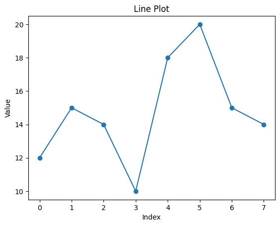

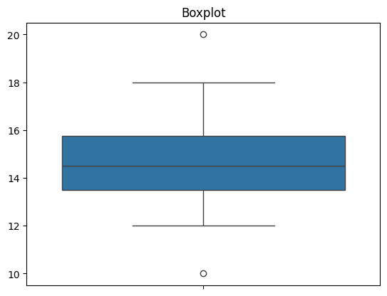

```python
import matplotlib.pyplot as plt
import seaborn as sns

# Sample data
data = [12, 15, 14, 10, 18, 20, 15, 14]

# Line plot using Matplotlib
plt.plot(data, marker='o')
plt.title("Line Plot")
plt.xlabel("Index")
plt.ylabel("Value")
plt.show()

# Boxplot using Seaborn
sns.boxplot(data=data)
plt.title("Boxplot")
plt.show()
```

### Practice Questions:

1. Create a bar chart for sales data of 5 products using Matplotlib.
2. Generate a histogram for random data of size 100 using Seaborn.
3. Create a scatter plot with a regression line using Seaborn.

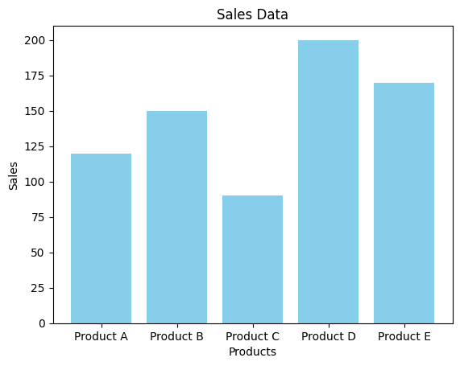

```python
# Create a bar chart for sales data of 5 products using Matplotlib:

import matplotlib.pyplot as plt

# Sales data
products = ['Product A', 'Product B', 'Product C', 'Product D', 'Product E']
sales = [120, 150, 90, 200, 170]

# Creating the bar chart
plt.bar(products, sales, color='skyblue')
plt.title('Sales Data')
plt.xlabel('Products')
plt.ylabel('Sales')
plt.show()
```

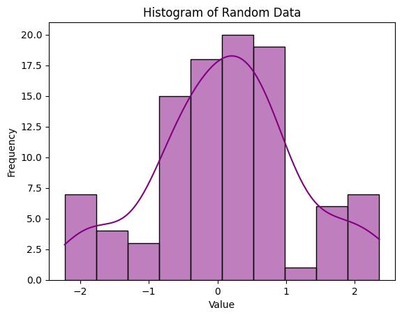

```python
# Generate a histogram for random data of size 100 using Seaborn:

import seaborn as sns
import numpy as np
import matplotlib.pyplot as plt

# Generating random data
random_data = np.random.randn(100)

# Creating the histogram
sns.histplot(random_data, bins=10, kde=True, color='purple')
# In the context of Seaborn's histplot function, the kde parameter stands for Kernel Density Estimate.
# When you set kde=True, it adds a smooth curve over the histogram, which represents the estimated probability density function of the data.

# This can be particularly useful for visualizing the distribution of data in a more continuous manner,
# as opposed to the discrete bins of a histogram. The KDE curve helps to identify
# patterns and trends in the data that might not be immediately apparent from the histogram alone.
plt.title('Histogram of Random Data')
plt.xlabel('Value')
plt.ylabel('Frequency')
plt.show()
```

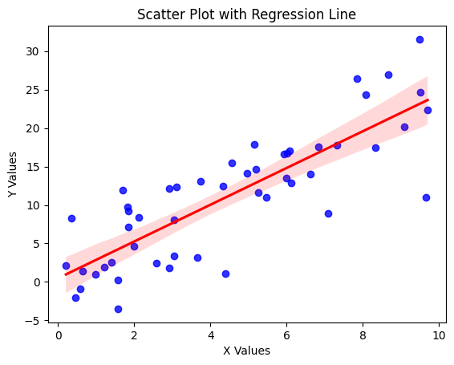

```python
# Create a scatter plot with a regression line using Seaborn:

import seaborn as sns
import numpy as np
import matplotlib.pyplot as plt

# Generating sample data
np.random.seed(42)
x = np.random.rand(50) * 10  # Random x values
y = 2.5 * x + np.random.randn(50) * 5  # Linear relation with noise

# Creating the scatter plot with regression line
sns.regplot(x=x, y=y, scatter_kws={'color': 'blue'}, line_kws={'color': 'red'})
plt.title('Scatter Plot with Regression Line')
plt.xlabel('X Values')
plt.ylabel('Y Values')
plt.show()
```

# Data Analysis Practice Questions (Personalized by Student Name)

1. Create a NumPy array with the values [10, 20, 30, 40, 50]. Add your name as a string (e.g., "John") at the end of the array and print the resulting array.
2. Create a Pandas DataFrame with columns "Name", "Age", and "Class". Include your name, your age, and a random class assignment (e.g., "A", "B", or "C") as the first row. Print the DataFrame.
3. Create a line plot using Matplotlib where the x-axis represents the letters of your name (e.g., ['J', 'O', 'H', 'N']) and the y-axis represents the number of times each letter appears in your name.
4. Generate a NumPy array of 5 random numbers. Rename the array variable to include your name as a suffix (e.g., `random_numbers_John`). Find the sum of the array elements.
5. Create a DataFrame with columns "Product", "Price", and "Seller". Add at least three products and prices. For the "Seller" column, include your name for each row. Display only the rows where the price is greater than 50.
6. Create a bar chart showing sales data for 5 products. Label the title of the chart with your name (e.g., "John's Sales Data").
7. Generate a histogram with 50 random numbers using Seaborn. Use your name as part of the figure's title (e.g., "Distribution of Random Numbers by John").
8. Create a 3x3 NumPy matrix with random integers between 1 and 10. Name the matrix variable as `matrix_<YourName>` (e.g., `matrix_John`). Calculate the sum of all elements in the matrix.
9. Load a CSV file into a Pandas DataFrame. Add a column labeled "Reviewer" and fill it with your name for all rows. Display the first 5 rows of the modified DataFrame.
10. Create a scatter plot with a regression line using Seaborn. Use random `x` values and calculate `y` values using the formula `y = 2x + noise`. Title the chart with your name (e.g., "John's Scatter Plot with Regression Line").